# SPOOKY text analysis

Ayano Kase

February 4, 2018

## Setup the libraries

First we want to install and load libraries we need along the way. Note that the following code is completely reproducible – you don’t need to add any code on your own to make it run.

```r
packages.used <- c("ggplot2", "dplyr", "tibble", "tidyr",  "stringr", "tidytext", "topicmodels", "wordcloud", "ggridges","ggraph","igraph")

# check packages that need to be installed.
packages.needed <- setdiff(packages.used, intersect(installed.packages()[,1], packages.used))

# install additional packages
if(length(packages.needed) > 0) {
  install.packages(packages.needed, dependencies = TRUE, repos = 'http://cran.us.r-project.org')
}

library(ggplot2)
library(dplyr)
library(tibble)
library(tidyr)
library(stringr)
library(tidytext)
library(ggridges)
library(ggraph)
library(igraph)
```

## Read in the data

The following code assumes that the dataset `spooky.csv` lives in a `data` folder (and that we are inside a `docs` folder).

```r
spooky <- read.csv('../data/spooky.csv', as.is = TRUE)
```

Let’s first remind ourselves of the structure of the data.

```r
head(spooky)
```

|  | id | text | author |
| --- | --- | --- | --- |
| 1 | id26305 | This process, however, afforded me no means of ascertaining the dimensions of my dungeon; as I might make its circuit, and return to the point whence I set out, without being aware of the fact; so per… | EAP |
| 2 | id17569 | It never once occurred to me that the fumbling might be a mere mistake. | HPL |
| 3 | id11008 | In his left hand was a gold snuff box, from which, as he capered down the hill, cutting all manner of fantastic steps, he took snuff incessantly with an air of the greatest possible self satisfaction. | EAP |
| 4 | id27763 | How lovely is spring As we looked from Windsor Terrace on the sixteen fertile counties spread beneath, speckled by happy cottages and wealthier towns, all looked as in former years, heart cheering and… | MWS |
| 5 | id12958 | Finding nothing else, not even gold, the Superintendent abandoned his attempts; but a perplexed look occasionally steals over his countenance as he sits thinking at his desk. | HPL |
| 6 | id22965 | A youth passed in solitude, my best years spent under your gentle and feminine fosterage, has so refined the groundwork of my character that I cannot overcome an intense distaste to the usual brutalit… | MWS |

```r
summary(spooky)
```

```
##       id                text              author
##  Length:19579       Length:19579       Length:19579
##  Class :character   Class :character   Class :character
##  Mode  :character   Mode  :character   Mode  :character
```

We see from the above that each row of our data contains a unique ID, a single sentence text excerpt, and an abbreviated author name. `HPL` is Lovecraft, `MWS` is Shelly, and `EAP` is Poe. We finally note that there are no missing values, and we change author name to be a factor variable, which will help us later on.

```r
sum(is.na(spooky))
```

```
## [1] 0
```

```r
spooky$author <- as.factor(spooky$author)
```

## Punctuation analysis

Authors have different writing styles. Thus we want to analyze their use of punctuations. We look at the author’s use of five types of punctuation marks: commas, question marks, colons, semi-colons, and quotation marks.

```r
# filter text data by author and store in new vector
EAP <- filter(spooky, author == "EAP")$text
HPL <- filter(spooky, author == "HPL")$text
MWS <- filter(spooky, author == "MWS")$text

# count the number of each punctuation for each author and store them in a vector
punc_EAP <- c(sum(str_count(EAP,',')),sum(str_count(EAP,'[?]')),sum(str_count(EAP,'[:]')),sum(str_count(EAP,';')),sum(str_count(EAP,'["]')))
punc_HPL <- c(sum(str_count(HPL,',')),sum(str_count(HPL,'[?]')),sum(str_count(HPL,'[:]')),sum(str_count(HPL,';')),sum(str_count(HPL,'["]')))
punc_MWS <- c(sum(str_count(MWS,',')),sum(str_count(MWS,'[?]')),sum(str_count(MWS,'[:]')),sum(str_count(MWS,';')),sum(str_count(MWS,'["]')))

#create a dataframe
punc_value <- c(punc_EAP, punc_HPL, punc_MWS)
punc_type <- c("comma","questionmark","colon","semicolon","quotation","comma","questionmark","colon","semicolon","quotation","comma","questionmark","colon","semicolon","quotation")
punc_type <- as.factor(punc_type)
authors <- c("EAP","EAP","EAP","EAP","EAP","HPL","HPL","HPL","HPL","HPL","MWS","MWS","MWS","MWS","MWS")
punc <- data.frame(punc_value, punc_type, authors)
punc
```

| punc_value | punc_type | authors |
| --- | --- | --- |
| 17594 | comma | EAP |
| 510 | questionmark | EAP |
| 176 | colon | EAP |
| 1354 | semicolon | EAP |
| 2987 | quotation | EAP |
| 8581 | comma | HPL |
| 169 | questionmark | HPL |
| 47 | colon | HPL |
| 1143 | semicolon | HPL |
| 513 | quotation | HPL |

[output cut: 5 more lines]

```r
punc$punc_type <- factor(punc$punc_type, levels = punc$punc_type[order(punc$punc_value)])
```

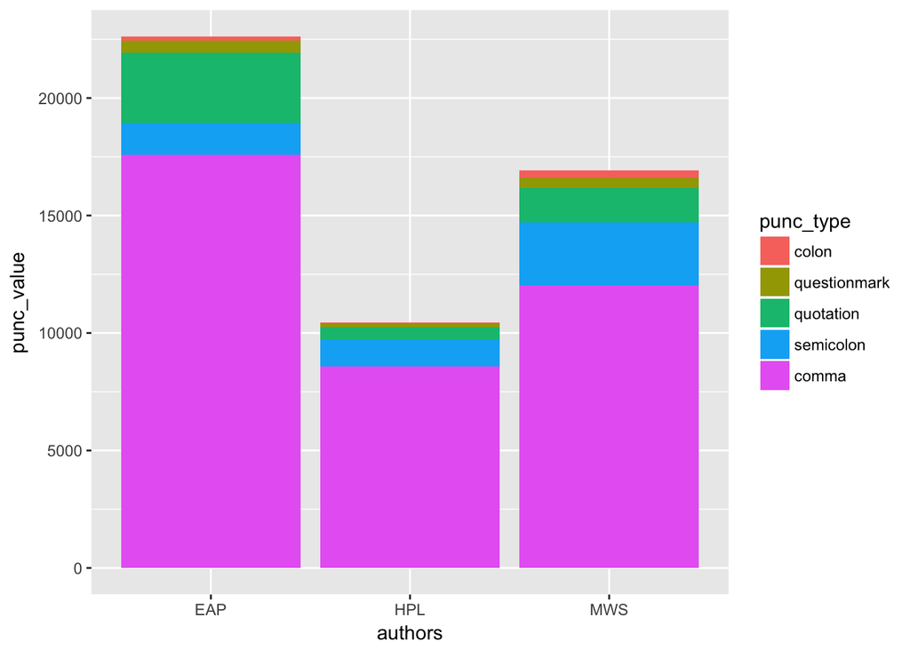

```r
#png("../figs/punc_bargraph.png")
ggplot(data = punc, aes(x=authors,y=punc_value, fill = punc_type, order = -as.numeric(punc_type)))+
  geom_bar(stat = "identity")
```

```r
#dev.off()
```

```r
# calculate the avergae number of each puctuation mark in a sentence
avgpunc_EAP <- round(punc_EAP/length(EAP),2)
avgpunc_HPL <- round(punc_HPL/length(HPL),2)
avgpunc_MWS <- round(punc_MWS/length(MWS),2)
```

## Word frequency

Next, we will try to look at word frequency. We’ll use tf-idf as an index to indicate how frequently a certain author uses a word relative to the frequency that all the authors use the word.

```r
# first thing first, clean the data
# filter stopwords and drop punctuations
spooky_wrd <- unnest_tokens(spooky, word, text)
spooky_wrd <- anti_join(spooky_wrd, stop_words, by = "word")

# count frequency
# calculate and bind the term frequency and inverse document frequency of a tidy text dataset
frequency <- count(spooky_wrd, author, word)
tf_idf    <- bind_tf_idf(frequency, word, author, n)
head(tf_idf)
```

| author | word | n | tf | idf | tf_idf |
| --- | --- | --- | --- | --- | --- |
| EAP |  | 9 | 1.235754e-04 | 1.098612 | 1.357615e-04 |
| EAP | rial | 1 | 1.373061e-05 | 1.098612 | 1.508461e-05 |
| EAP | ronaut | 2 | 2.746121e-05 | 1.098612 | 3.016922e-05 |
| EAP | ronauts | 1 | 1.373061e-05 | 1.098612 | 1.508461e-05 |
| EAP | rostation | 1 | 1.373061e-05 | 1.098612 | 1.508461e-05 |
| EAP | schylus | 1 | 1.373061e-05 | 1.098612 | 1.508461e-05 |

```r
tail(tf_idf)
```

| author | word | n | tf | idf | tf_idf |
| --- | --- | --- | --- | --- | --- |
| MWS | youth's | 1 | 1.600205e-05 | 0.4054651 | 6.488272e-06 |
| MWS | youthful | 10 | 1.600205e-04 | 0.0000000 | 0.000000e+00 |
| MWS | youths | 2 | 3.200410e-05 | 0.4054651 | 1.297654e-05 |
| MWS | zaimi | 2 | 3.200410e-05 | 1.0986123 | 3.516009e-05 |
| MWS | zeal | 7 | 1.120143e-04 | 0.0000000 | 0.000000e+00 |
| MWS | zest | 3 | 4.800614e-05 | 0.0000000 | 0.000000e+00 |

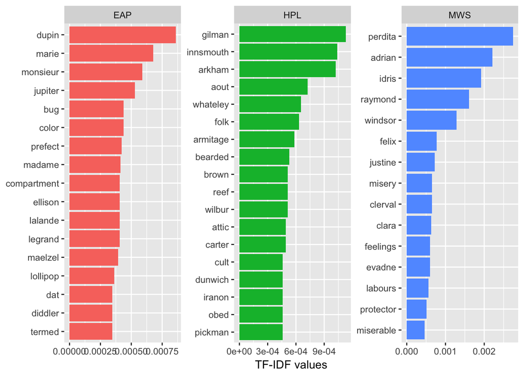

```r
tf_idf    <- arrange(tf_idf, desc(tf_idf))
tf_idf    <- mutate(tf_idf, word = factor(word, levels = rev(unique(word))))

# Grab the top twenty tf_idf scores in all the words for each author
tf_idf <- ungroup(top_n(group_by(tf_idf, author), 15, tf_idf))

#png("../figs/basic_tfidf.png")
ggplot(tf_idf) +
  geom_col(aes(word, tf_idf, fill = author)) +
  labs(x = NULL, y = "tf-idf") +
  theme(legend.position = "none") +
  facet_wrap(~ author, ncol = 3, scales = "free") +
  coord_flip() +
  labs(y = "TF-IDF values")
```

```r
#dev.off()
```

We wil extend this analysis a bit further. Next, let’s look at the frequency of pairs of words and map it out.

```r
#extract pairs using unnest_tokens
bigram_spooky <- select(spooky,author, text)
bigram_spooky <- unnest_tokens(bigram_spooky,bigram, text, token = "ngrams", n = 2)
sample_n(bigram_spooky, 5)
```

|  | author | bigram |
| --- | --- | --- |
| 357505 | MWS | for only |
| 77334 | EAP | out of |
| 141401 | EAP | case against |
| 508212 | MWS | the till |
| 114879 | EAP | brink of |

```r
#filter out stop_words
#seprate the bigrams, filter the words, and unite them back
bi_sep <- separate(bigram_spooky, bigram, c("word1", "word2"), sep = " ")

bi_filt <- filter(bi_sep, !word1 %in% stop_words$word)
bi_filt <- filter(bi_filt, !word2 %in% stop_words$word)

bigram_counts <- count(bi_filt, word1, word2, sort = TRUE)

bigram_spooky <- unite(bi_filt, bigram, word1, word2, sep = " ")
```

```r
#extract tf-idf values
frequency <- count(bigram_spooky, author, bigram)
tf_idf    <- bind_tf_idf(frequency, bigram, author, n)
head(tf_idf)
```

| author | bigram | n | tf | idf | tf_idf |
| --- | --- | --- | --- | --- | --- |
| EAP | cder | 1 | 5.377501e-05 | 1.098612 | 5.907788e-05 |
| EAP | faire | 1 | 5.377501e-05 | 1.098612 | 5.907788e-05 |
| EAP | la | 2 | 1.075500e-04 | 1.098612 | 1.181558e-04 |
| EAP | parir | 1 | 5.377501e-05 | 1.098612 | 5.907788e-05 |
| EAP | tte | 2 | 1.075500e-04 | 1.098612 | 1.181558e-04 |
| EAP | vis | 1 | 5.377501e-05 | 1.098612 | 5.907788e-05 |

```r
tail(tf_idf)
```

| author | bigram | n | tf | idf | tf_idf |
| --- | --- | --- | --- | --- | --- |
| MWS | youthful revelry | 1 | 6.649378e-05 | 1.098612 | 7.305089e-05 |
| MWS | youthful tyro | 1 | 6.649378e-05 | 1.098612 | 7.305089e-05 |
| MWS | youthful womanhood | 1 | 6.649378e-05 | 1.098612 | 7.305089e-05 |
| MWS | youths nobles | 1 | 6.649378e-05 | 1.098612 | 7.305089e-05 |
| MWS | zaimi ambassador | 1 | 6.649378e-05 | 1.098612 | 7.305089e-05 |
| MWS | zeal pardon | 1 | 6.649378e-05 | 1.098612 | 7.305089e-05 |

```r
tf_idf    <- arrange(tf_idf, desc(tf_idf))

tf_idf    <- mutate(tf_idf, bigram = factor(bigram, levels = rev(unique(bigram))))
tf_idf <- group_by(tf_idf, author)

# Grab the top ten tf_idf scores in all the words
tf_idf_10 <- top_n(tf_idf,10,tf_idf)
ungroup(tf_idf_10)
```

| author | bigram | n | tf | idf | tf_idf |
| --- | --- | --- | --- | --- | --- |
| MWS | lord raymond | 27 | 0.0017953321 | 1.098612 | 0.0019723739 |
| MWS | fellow creatures | 22 | 0.0014628632 | 1.098612 | 0.0016071195 |
| EAP | ha ha | 22 | 0.0011830501 | 1.098612 | 0.0012997134 |
| EAP | main compartment | 21 | 0.0011292751 | 1.098612 | 0.0012406355 |
| EAP | madame lalande | 20 | 0.0010755001 | 1.098612 | 0.0011815576 |
| EAP | chess player | 18 | 0.0009679501 | 1.098612 | 0.0010634019 |
| MWS | native country | 14 | 0.0009309130 | 1.098612 | 0.0010227124 |
| HPL | heh heh | 17 | 0.0008241625 | 1.098612 | 0.0009054351 |
| HPL | shunned house | 16 | 0.0007756824 | 1.098612 | 0.0008521742 |
| EAP | tea pot | 13 | 0.0006990751 | 1.098612 | 0.0007680125 |

[output cut: 27 more lines]

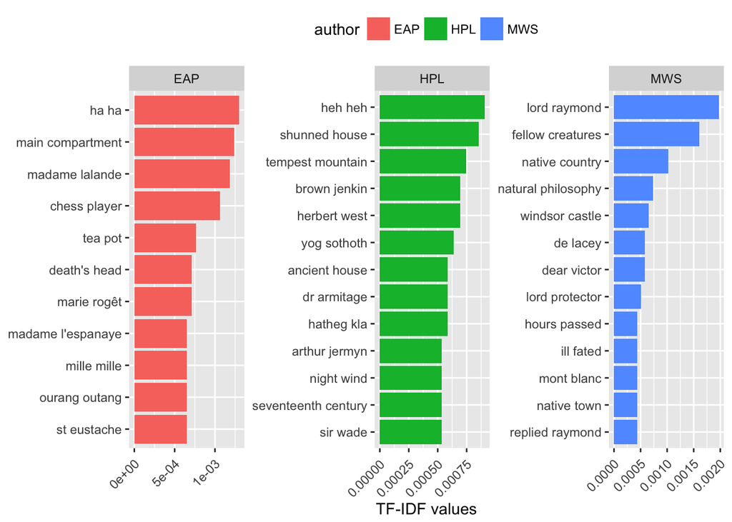

```r
# plot the bigrams with highest tf-idf values per author
#png("../figs/Bigram.png")
ggplot(tf_idf_10) +
  geom_col(aes(bigram, tf_idf, fill = author)) +
  labs(x = NULL, y = "TF-IDF values") +
  theme(legend.position = "top", axis.text.x  = element_text(angle=45, hjust=1, vjust=0.9))+
  facet_wrap(~ author, ncol = 3, scales = "free") +
  coord_flip()
```

```r
#dev.off()
```

Next, we will make a network plot for each individual author.

```r
# create a function that would produce network plot for each author
# input parameters: author, minimum count for bigram graph
plot_bigram_net_author <- function(name, bimin){

  filt <- filter(bigram_spooky, author == name)

  sep <- separate(filt, bigram, c("word1", "word2"), sep = " ")

  #filter for stop words
  bi_filt <- filter(sep, !word1 %in% stop_words$word)
  bi_filt <- filter(bi_filt, !word2 %in% stop_words$word)

  bigram_graph <- count(bi_filt, word1, word2, sort = TRUE)
  bigram_graph <- filter(bigram_graph, n > bimin)
  bigram_graph <- graph_from_data_frame(bigram_graph)

  set.seed(1234)

  a <- grid::arrow(type = "closed", length = unit(.08, "inches"))

  # graph the network plot
  ggraph(bigram_graph, layout = "fr") +
    geom_edge_link(aes(edge_alpha = n), show.legend = FALSE,
                 arrow = a, end_cap = circle(.07, 'inches')) +
    geom_node_point(color = "pink", size = 2) +
    geom_node_text(aes(label = name), vjust = 1, hjust = 1) +
    theme_void()
}
```

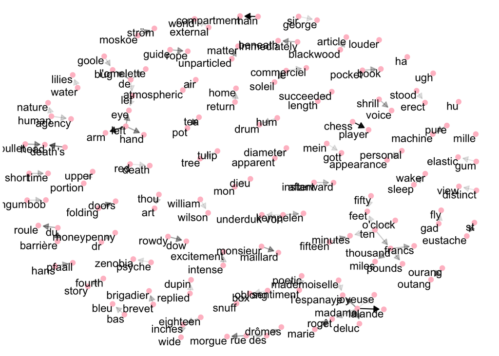

```r
# produce network plots for each author
#png("../figs/network_EAP.png")
plot_bigram_net_author("EAP",4)
```

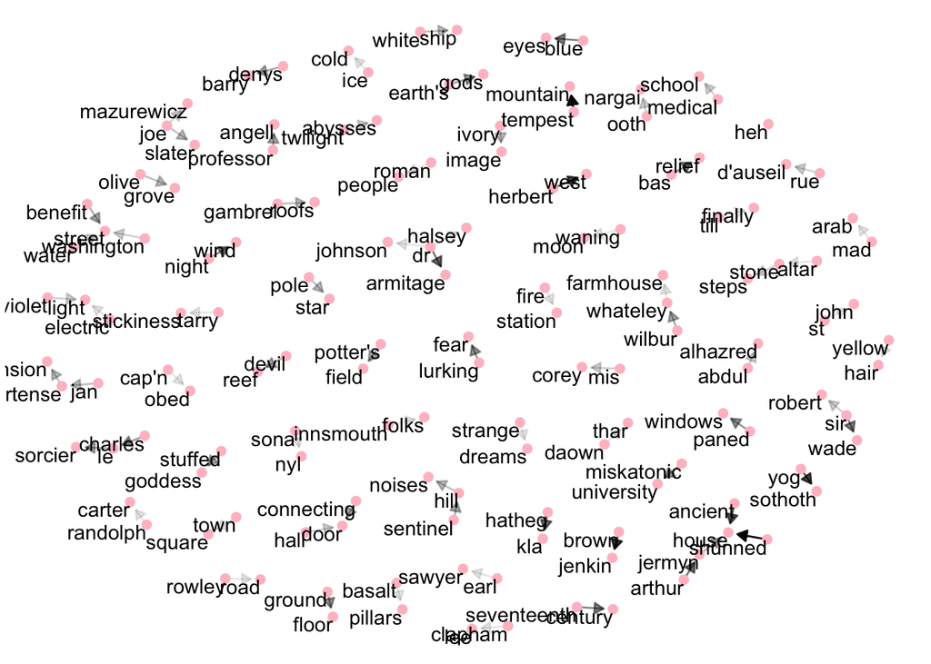

```r
#dev.off()

#png("../figs/network_HPL.png")
plot_bigram_net_author("HPL",4)
```

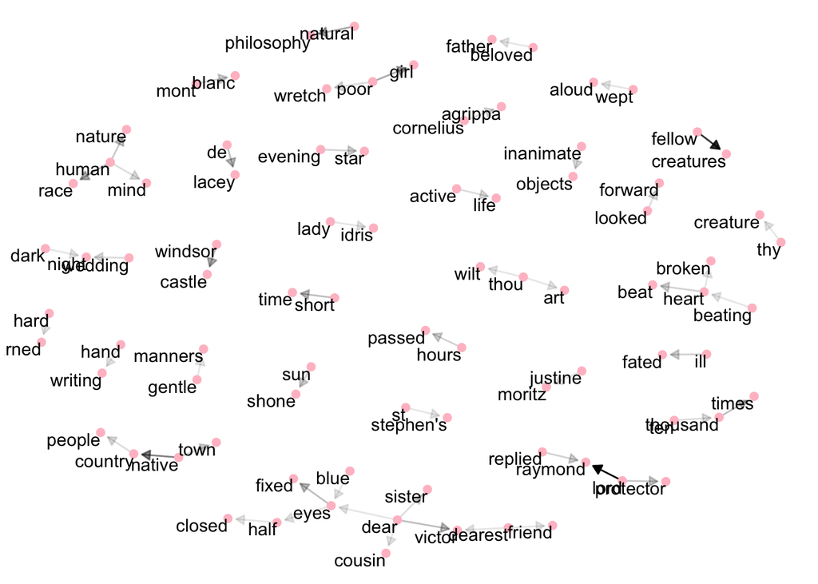

```r
#dev.off()

#png("../figs/network_MWS.png")
plot_bigram_net_author("MWS",3)
```

```r
#dev.off()
```

## Sentiment Analysis

Here, we will focus on negative sentiments.

```r
# using the nrc sentiment lexicon, filter only for the negative words
nrc_neg <- filter(get_sentiments('nrc'), sentiment == "negative")
nrc_neg
```

| word | sentiment |
| --- | --- |
| abandon | negative |
| abandoned | negative |
| abandonment | negative |
| abduction | negative |
| aberrant | negative |
| aberration | negative |
| abhor | negative |
| abhorrent | negative |
| abject | negative |
| abnormal | negative |

[output cut: 3314 more lines]

```r
# join the list of negative words with spooky-wrd
negative <- inner_join(spooky_wrd, nrc_neg, by = "word")
head(negative)
```

|  | id | author | word | sentiment |
| --- | --- | --- | --- | --- |
| 1 | id26305 | EAP | dungeon | negative |
| 2 | id17569 | HPL | mistake | negative |
| 3 | id11008 | EAP | cutting | negative |
| 4 | id12958 | HPL | abandoned | negative |
| 5 | id12958 | HPL | perplexed | negative |
| 6 | id22965 | MWS | spent | negative |

```r
count(negative, word, sort = TRUE)
```

| word | n |
| --- | --- |
| death | 380 |
| words | 292 |
| fear | 240 |
| black | 198 |
| horror | 198 |
| lost | 181 |
| spoke | 163 |
| ancient | 161 |
| doubt | 159 |
| fell | 157 |

[output cut: 2131 more lines]

Now we plot a frequency comparison of these “negative” words. Namely, we show the frequencies of the overall most frequently-used negative words compared among the three authors.

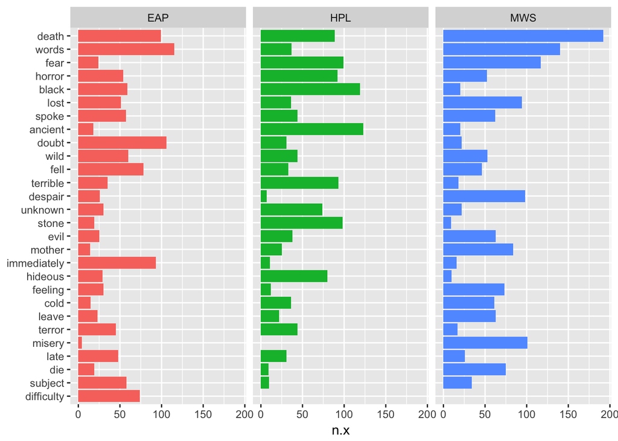

```r
neg_words     <- count(group_by(negative, word, author))
neg_words_all <- count(group_by(negative, word))

neg_words <- left_join(neg_words, neg_words_all, by = "word")
neg_words <- arrange(neg_words, desc(n.y))
neg_words <- ungroup(head(neg_words, 81))


#png("../figs/negative.png")
ggplot(neg_words) +
  geom_col(aes(reorder(word, n.y, FUN = min), n.x, fill = author)) +
  xlab(NULL) +
  coord_flip() +
  facet_wrap(~ author) +
  theme(legend.position = "none")
```

```r
#dev.off()
```

The above analysis, however, did not take into account negated negatives, such as “not good”. The next analysis will allow us to compare the occurences of positive and negative words preceded by the word “not”.

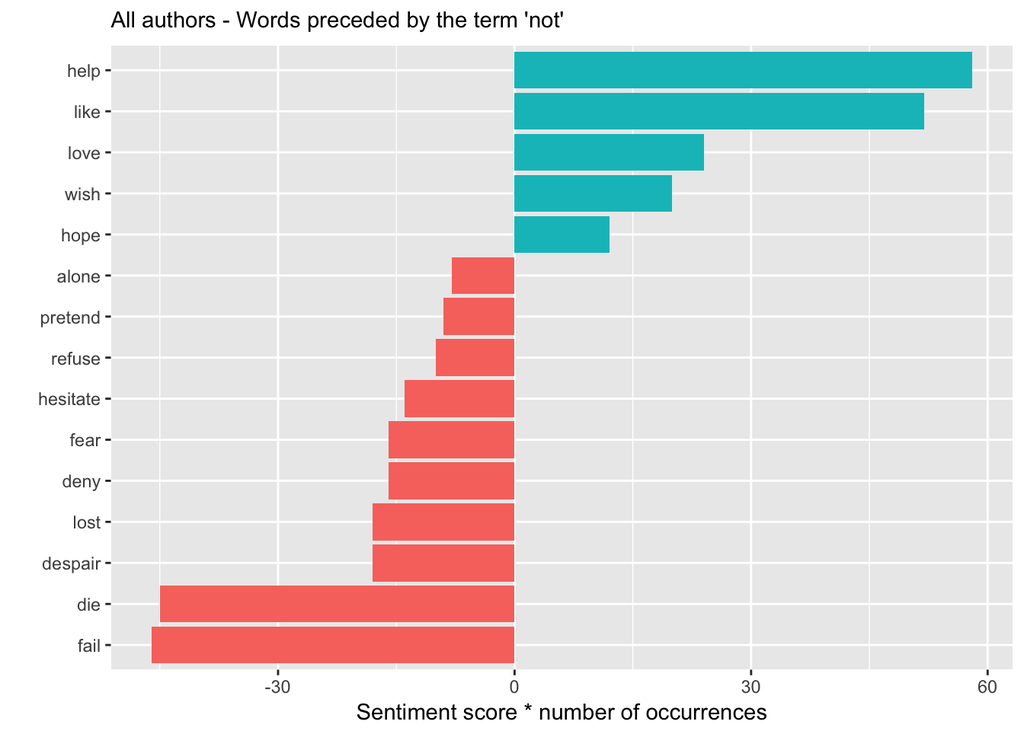

```r
# filter through bigram procedure
bi_sep <- select(spooky, author, text)
bi_sep <- unnest_tokens(bi_sep, bigram, text, token = "ngrams", n = 2)
bi_sep <- separate(bi_sep,bigram, c("word1", "word2"), sep = " ")

# all authors
a <- filter(bi_sep, word1 == "not")
a <- inner_join(a, get_sentiments("afinn"), by = c(word2 = "word"))
a <- count(a, word1, word2, score, sort = TRUE)
a <- ungroup(a)
a <- mutate(a, contribution = n * score)
a <- arrange(a, desc(abs(contribution)))
a <- head(a,15)
a <- mutate(a, word2 = reorder(word2, contribution))

#png("../figs/a.png")
ggplot(a, aes(word2, n * score, fill = n * score > 0)) +
  geom_col(show.legend = FALSE) +
  xlab("") +
  ylab("Sentiment score * number of occurrences") +
  coord_flip() +
  theme(plot.title = element_text(size=11)) +
  ggtitle("All authors - Words preceded by the term 'not'")
```

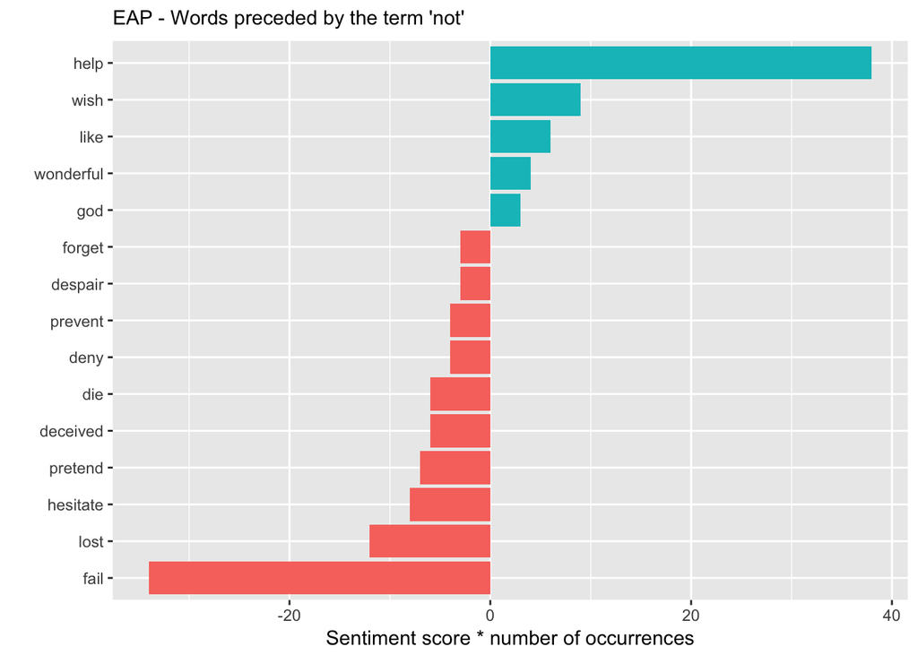

```r
#dev.off()

# EAP
b <- filter(bi_sep, author == "EAP")
b <- filter(b, word1 == "not")
b <- inner_join(b, get_sentiments("afinn"), by = c(word2 = "word"))
b <- count(b, word1, word2, score, sort = TRUE)
b <- ungroup(b)
b <- mutate(b, contribution = n * score)
b <- arrange(b, desc(abs(contribution)))
b <- head(b, 15)
b <- mutate(b,word2 = reorder(word2, contribution))

#png("../figs/b.png")
ggplot(b, aes(word2, n * score, fill = n * score > 0)) +
  geom_col(show.legend = FALSE) +
  xlab("") +
  ylab("Sentiment score * number of occurrences") +
  coord_flip() +
  theme(plot.title = element_text(size=11)) +
  ggtitle("EAP - Words preceded by the term 'not'")
```

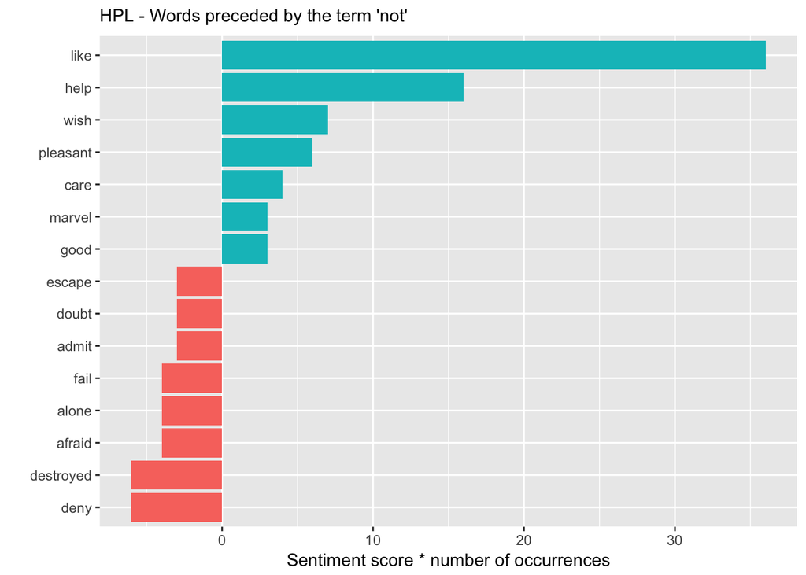

```r
#dev.off()

# HPL
c <- filter(bi_sep, author == "HPL")
c <- filter(c, word1 == "not")
c <- inner_join(c,get_sentiments("afinn"), by = c(word2 = "word"))
c <- count(c, word1, word2, score, sort = TRUE)
c <- ungroup(c)
c <- mutate(c, contribution = n * score)
c <- arrange(c, desc(abs(contribution)))
c <- head(c, 15)
c <- mutate(c, word2 = reorder(word2, contribution))

#png("../figs/c.png")
ggplot(c, aes(word2, n * score, fill = n * score > 0)) +
  geom_col(show.legend = FALSE) +
  xlab("") +
  ylab("Sentiment score * number of occurrences") +
  coord_flip() +
  theme(plot.title = element_text(size=11)) +
  ggtitle("HPL - Words preceded by the term 'not'")
```

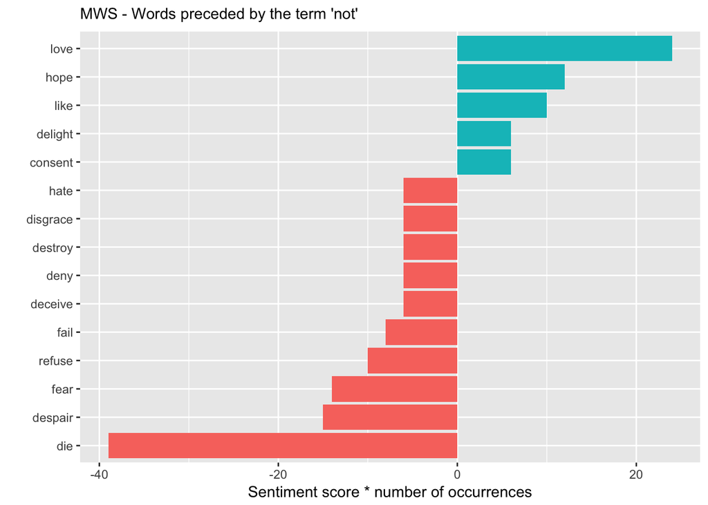

```r
#dev.off()

# MWS
d <- filter(bi_sep, author == "MWS")
d <- filter(d, word1 == "not")
d <- inner_join(d, get_sentiments("afinn"), by = c(word2 = "word"))
d <- count(d, word1, word2, score, sort = TRUE)
d <- ungroup(d)
d <- mutate(d, contribution = n * score)
d <- arrange(d, desc(abs(contribution)))
d <- head(d, 15)
d <- mutate(d, word2 = reorder(word2, contribution))

#png("../figs/d.png")
ggplot(d, aes(word2, n * score, fill = n * score > 0)) +
  geom_col(show.legend = FALSE) +
  xlab("") +
  ylab("Sentiment score * number of occurrences") +
  coord_flip() +
  theme(plot.title = element_text(size=11)) +
  ggtitle("MWS - Words preceded by the term 'not'")
```

```r
#dev.off()
```